# Regression Interpretation, Classification Metrics & Advertising Prediction

**Cameron Batts** — Linear Regression · Logistic Regression · Classification Metrics

```python
import joblib

import numpy as np
import pandas as pd
import seaborn as sns
from sklearn.linear_model import LinearRegression
```

```python
multiple_linear_regression = joblib.load('case_data/linear_regression.joblib')
```

```python
multiple_linear_regression.summary()
```

OLS Regression Results

| Dep. Variable: | log_selling_price | R-squared: | 0.779 |
| --- | --- | --- | --- |
| Model: | OLS | Adj. R-squared: | 0.777 |
| Method: | Least Squares | F-statistic: | 583.4 |
| Date: | Wed, 22 Apr 2026 | Prob (F-statistic): | 0.00 |
| Time: | 12:44:49 | Log-Likelihood: | -2125.1 |
| No. Observations: | 4340 | AIC: | 4304. |
| Df Residuals: | 4313 | BIC: | 4476. |
| Df Model: | 26 |  |  |
| Covariance Type: | nonrobust |  |  |

|  | coef | std err | t | P>\|t\| | [0.025 | 0.975] |
| --- | --- | --- | --- | --- | --- | --- |
| const | 12.4959 | 0.059 | 212.070 | 0.000 | 12.380 | 12.611 |
| year | 0.1178 | 0.002 | 66.227 | 0.000 | 0.114 | 0.121 |
| km_driven | -0.0008 | 0.000 | -5.354 | 0.000 | -0.001 | -0.001 |
| fuel_Diesel | 0.3954 | 0.015 | 27.002 | 0.000 | 0.367 | 0.424 |
| fuel_Other | -0.1087 | 0.051 | -2.148 | 0.032 | -0.208 | -0.009 |
| seller_type_Individual | -0.1047 | 0.016 | -6.728 | 0.000 | -0.135 | -0.074 |
| seller_type_Trustmark Dealer | 0.3715 | 0.042 | 8.849 | 0.000 | 0.289 | 0.454 |
| owner_Other | -0.0820 | 0.042 | -1.963 | 0.050 | -0.164 | -0.000 |
| owner_Second Owner | -0.0328 | 0.015 | -2.119 | 0.034 | -0.063 | -0.002 |
| owner_Third Owner | -0.0979 | 0.026 | -3.798 | 0.000 | -0.148 | -0.047 |
| brand_BMW | 0.1236 | 0.082 | 1.513 | 0.130 | -0.037 | 0.284 |
| brand_Chevrolet | -1.7207 | 0.060 | -28.876 | 0.000 | -1.838 | -1.604 |
| brand_Datsun | -1.7509 | 0.084 | -20.753 | 0.000 | -1.916 | -1.585 |
| brand_Fiat | -1.6262 | 0.083 | -19.481 | 0.000 | -1.790 | -1.463 |
| brand_Ford | -1.3177 | 0.058 | -22.858 | 0.000 | -1.431 | -1.205 |
| brand_Honda | -1.1191 | 0.058 | -19.433 | 0.000 | -1.232 | -1.006 |
| brand_Hyundai | -1.3317 | 0.054 | -24.594 | 0.000 | -1.438 | -1.226 |
| brand_Mahindra | -1.1678 | 0.056 | -20.824 | 0.000 | -1.278 | -1.058 |
| brand_Maruti | -1.4619 | 0.054 | -27.191 | 0.000 | -1.567 | -1.357 |
| brand_Mercedes-Benz | 0.2986 | 0.084 | 3.540 | 0.000 | 0.133 | 0.464 |
| brand_Nissan | -1.3616 | 0.072 | -18.971 | 0.000 | -1.502 | -1.221 |
| brand_Other | -0.2968 | 0.084 | -3.536 | 0.000 | -0.461 | -0.132 |
| brand_Renault | -1.5154 | 0.062 | -24.615 | 0.000 | -1.636 | -1.395 |
| brand_Skoda | -1.0981 | 0.070 | -15.577 | 0.000 | -1.236 | -0.960 |
| brand_Tata | -1.8146 | 0.056 | -32.224 | 0.000 | -1.925 | -1.704 |
| brand_Toyota | -0.7292 | 0.059 | -12.350 | 0.000 | -0.845 | -0.613 |
| brand_Volkswagen | -1.2389 | 0.064 | -19.276 | 0.000 | -1.365 | -1.113 |

| Omnibus: | 133.156 | Durbin-Watson: | 1.874 |
| --- | --- | --- | --- |
| Prob(Omnibus): | 0.000 | Jarque-Bera (JB): | 326.637 |
| Skew: | 0.109 | Prob(JB): | 1.18e-71 |
| Kurtosis: | 4.326 | Cond. No. | 3.04e+03 |

Notes:  
[1] Standard Errors assume that the covariance matrix of the errors is correctly specified.  
[2] The condition number is large, 3.04e+03. This might indicate that there are  
strong multicollinearity or other numerical problems.

Holding all other variables constant, a car branded as a Maruti is associated with an approximate 76.82% decrease in selling price compared to the baseline brand. Using (e^-1.4619)-1

Holding all other variables such as mileage and fuel type constant, each one-year increase in the car's model year is associated with an approximate 12.5% increase in the selling price using (e^.1178)-1=12%

Now, consider again the logistic regression model that we used to model the probability that a customer subscribes a term deposit for the Bank Marketing dataset.

```python
logistic_regression_model = joblib.load('case_data/logistic_regression.joblib')
```

Here is the model summary:

```python
logistic_regression_model.summary()
```

Logit Regression Results

| Dep. Variable: | y | No. Observations: | 45211 |
| --- | --- | --- | --- |
| Model: | Logit | Df Residuals: | 45185 |
| Method: | MLE | Df Model: | 25 |
| Date: | Wed, 22 Apr 2026 | Pseudo R-squ.: | 0.09451 |
| Time: | 12:44:49 | Log-Likelihood: | -14774. |
| converged: | True | LL-Null: | -16315. |
| Covariance Type: | nonrobust | LLR p-value: | 0.000 |

|  | coef | std err | z | P>\|z\| | [0.025 | 0.975] |
| --- | --- | --- | --- | --- | --- | --- |
| const | -1.2729 | 0.103 | -12.347 | 0.000 | -1.475 | -1.071 |
| age | 0.0045 | 0.002 | 2.407 | 0.016 | 0.001 | 0.008 |
| balance | 0.0211 | 0.004 | 5.145 | 0.000 | 0.013 | 0.029 |
| campaign | -0.1321 | 0.009 | -15.418 | 0.000 | -0.149 | -0.115 |
| previous | 0.0902 | 0.006 | 14.719 | 0.000 | 0.078 | 0.102 |
| job_blue-collar | -0.2321 | 0.062 | -3.745 | 0.000 | -0.354 | -0.111 |
| job_entrepreneur | -0.4052 | 0.108 | -3.759 | 0.000 | -0.616 | -0.194 |
| job_housemaid | -0.3983 | 0.114 | -3.490 | 0.000 | -0.622 | -0.175 |
| job_management | -0.1714 | 0.062 | -2.773 | 0.006 | -0.293 | -0.050 |
| job_retired | 0.4701 | 0.080 | 5.876 | 0.000 | 0.313 | 0.627 |
| job_self-employed | -0.2233 | 0.094 | -2.381 | 0.017 | -0.407 | -0.039 |
| job_services | -0.1902 | 0.071 | -2.673 | 0.008 | -0.330 | -0.051 |
| job_student | 0.4715 | 0.092 | 5.126 | 0.000 | 0.291 | 0.652 |
| job_technician | -0.2076 | 0.058 | -3.563 | 0.000 | -0.322 | -0.093 |
| job_unemployed | 0.0513 | 0.091 | 0.562 | 0.574 | -0.128 | 0.230 |
| job_unknown | -0.2314 | 0.196 | -1.182 | 0.237 | -0.615 | 0.152 |
| marital_divorced | -0.1844 | 0.056 | -3.282 | 0.001 | -0.294 | -0.074 |
| marital_married | -0.3437 | 0.039 | -8.907 | 0.000 | -0.419 | -0.268 |
| education_secondary | 0.1726 | 0.054 | 3.173 | 0.002 | 0.066 | 0.279 |
| education_tertiary | 0.4020 | 0.063 | 6.388 | 0.000 | 0.279 | 0.525 |
| education_unknown | 0.2823 | 0.087 | 3.234 | 0.001 | 0.111 | 0.453 |
| default_yes | -0.3472 | 0.148 | -2.352 | 0.019 | -0.637 | -0.058 |
| housing_yes | -0.6474 | 0.033 | -19.509 | 0.000 | -0.712 | -0.582 |
| loan_yes | -0.5841 | 0.051 | -11.408 | 0.000 | -0.684 | -0.484 |
| contact_telephone | -0.2077 | 0.061 | -3.415 | 0.001 | -0.327 | -0.089 |
| contact_unknown | -1.1324 | 0.049 | -23.143 | 0.000 | -1.228 | -1.036 |

And these are the model's coefficients after exponentiation.

```python
list(zip(logistic_regression_model.params.index, np.exp(logistic_regression_model.params.values)))
```

```
[('const', np.float64(0.2800305149314219)),
 ('age', np.float64(1.0044752145380202)),
 ('balance', np.float64(1.0213064724474892)),
 ('campaign', np.float64(0.8762774990962451)),
 ('previous', np.float64(1.0944009330533633)),
 ('job_blue-collar', np.float64(0.7928585082022306)),
 ('job_entrepreneur', np.float64(0.6668533914136384)),
 ('job_housemaid', np.float64(0.6714553977781069)),
 ('job_management', np.float64(0.8424780508168235)),
 ('job_retired', np.float64(1.6002173552302914)),
 ('job_self-employed', np.float64(0.7998729526865042)),
 ('job_services', np.float64(0.8268073698727474)),
 ('job_student', np.float64(1.602364279805471)),
 ('job_technician', np.float64(0.8125498927833217)),
 ('job_unemployed', np.float64(1.0526698376921393)),
 ('job_unknown', np.float64(0.7933912487973837)),
 ('marital_divorced', np.float64(0.8316200897732502)),
 ('marital_married', np.float64(0.7091613334472324)),
 ('education_secondary', np.float64(1.1884203914695188)),
 ('education_tertiary', np.float64(1.4948133136118265)),
 ('education_unknown', np.float64(1.3262240064333768)),
 ('default_yes', np.float64(0.7066392112323853)),
 ('housing_yes', np.float64(0.5233851851737711)),
 ('loan_yes', np.float64(0.5576202171093175)),
 ('contact_telephone', np.float64(0.8124475352065605)),
 ('contact_unknown', np.float64(0.3222585173026331))]
```

Holding all other variables constant, being self-employed is associated with a 20% decrease (less than 1), in the odds of subscribing to a term deposit compared to the baseline job category. 0.7998−1=−0.2002

Holding all other factors constant, for every one-unit increase in the customer's balance, the odds of subscribing to a term deposit increase by approximately 2.13%. Because this value is greater than 1, it indicates a positive relationship. 1.0213−1=0.0213 (or 2.13%).

Consider the following confusion matrix:

|  | **Predictions** |  | **0** | **1** |
| --- | --- | --- | --- | --- |
| **True labels** |  | **0** | 100 | 20 |
|  |  | **1** | 120 | 80 |

True Negatives (TN): 100 (Correctly predicted "No")

False Positives (FP): 20 (Incorrectly predicted "Yes")

False Negatives (FN): 120 (Incorrectly predicted "No")

True Positives (TP): 80 (Correctly predicted "Yes")

Total Observations: 100+20+120+80=320

Accuracy(Overall correctness)= TP+TN/Total 180/320 =0.563 or 56.3%

Precision (Reliability of a "Yes" prediction)= TP/TP+FP 80/100=0.8 or 80%

Recall (Ability to find all actual "Yes")= TP/TP+FN 80/(80+120)=0.4 or 40%

Specificity (Ability to find all actual "No")= TN/TN+FP 100/(100+20)=0.833 or 83.3%

Now, let's consider the following marketing data.

```python
marketing_data = pd.read_csv('case_data/marketing.csv')
```

```python
marketing_data.head()
```

|  | facebook | sales |
| --- | --- | --- |
| 0 | 45.36 | 72.52 |
| 1 | 47.16 | 60.48 |
| 2 | 55.08 | 67.16 |
| 3 | 49.56 | 72.20 |
| 4 | 12.96 | 28.48 |

- `facebook` measures the budget (in 1000s of USD) spent on an online marketing campaign for a product
- `sales` measures the sales (in 1000s of USD) induced by the campaign.

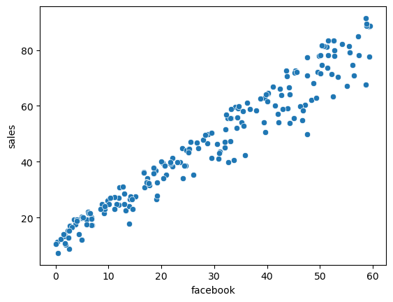

```python
_ = sns.scatterplot(x='facebook', y='sales', data=marketing_data)
```

```python
X = marketing_data['facebook'].values.reshape(-1, 1)
Y = marketing_data['sales']

Simple_Linear_Regression= LinearRegression()
Simple_Linear_Regression = LinearRegression().fit(X, Y)
Simple_Linear_Regression.score(X, Y)
```

```
0.9463557108459727
```

R2 approximately 94.6% of the variation in sales can be explained by the Facebook marketing budget

```python
prediction_data = pd.DataFrame({'facebook': pd.Series(50)})

prediction = Simple_Linear_Regression.predict(prediction_data.values)
print(f"The predicted sales for a $50,000 budget is: {prediction[0]:.2f}")
```

```
The predicted sales for a $50,000 budget is: 71.83
```

Formula used by the summary: 71.83=Intercept_coef+(facebook_coef×50)

```python
import statsmodels.formula.api as smf
simple_linear_regression_sm = smf.ols('sales ~ facebook', data=marketing_data).fit()
```

```python
print(simple_linear_regression_sm.summary())
```

```
                            OLS Regression Results
==============================================================================
Dep. Variable:                  sales   R-squared:                       0.946
Model:                            OLS   Adj. R-squared:                  0.946
Method:                 Least Squares   F-statistic:                     3493.
Date:                Wed, 22 Apr 2026   Prob (F-statistic):          9.72e-128
Time:                        12:44:49   Log-Likelihood:                -609.40
No. Observations:                 200   AIC:                             1223.
Df Residuals:                     198   BIC:                             1229.
Df Model:                           1
Covariance Type:            nonrobust
==============================================================================
                 coef    std err          t      P>|t|      [0.025      0.975]
------------------------------------------------------------------------------
Intercept     11.6375      0.674     17.263      0.000      10.308      12.967
facebook       1.2039      0.020     59.101      0.000       1.164       1.244
==============================================================================
Omnibus:                       20.420   Durbin-Watson:                   1.948
Prob(Omnibus):                  0.000   Jarque-Bera (JB):               23.417
Skew:                          -0.785   Prob(JB):                     8.22e-06
Kurtosis:                       3.585   Cond. No.                         61.7
==============================================================================

Notes:
[1] Standard Errors assume that the covariance matrix of the errors is correctly specified.
```